## Lab Worksheet 4

### Part 1: The dplyr pipe

The following questions in Part 1 are from Lab Worksheet 3. Answer these questions again, but this time use the dplyr pipe (`%>%`) in your answer.

**Question 1:** *In an in-class exercise, we made the following plot of the Sitka dataset:*

```r
# download the sitka data set:
sitka <- read.csv("http://wilkelab.org/classes/SDS348/data_sets/sitka.csv")
head(sitka)
```

```
##   size Time tree treat
## 1 4.51  152    1 ozone
## 2 4.98  174    1 ozone
## 3 5.41  201    1 ozone
## 4 5.90  227    1 ozone
## 5 6.15  258    1 ozone
## 6 4.24  152    2 ozone
```

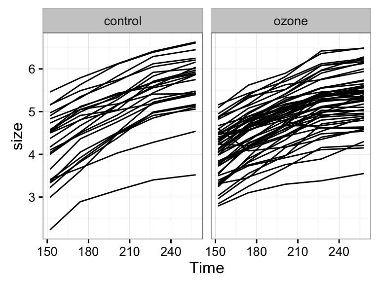

```r
ggplot(sitka, aes(x=Time, y=size, group=tree)) + geom_line() + facet_wrap(~treat)
```

*Now modify the plot so that the line for each tree is colored according to the maximum size of the tree.*

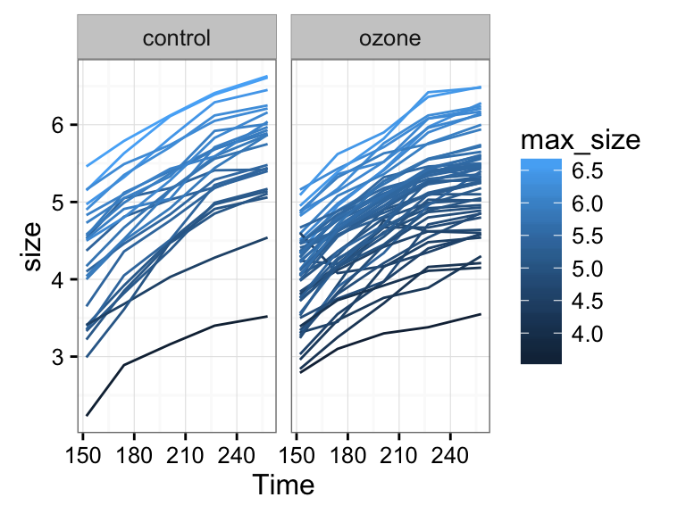

```r
sitka %>% group_by(tree) %>% mutate(max_size = max(size)) -> sitka_new
ggplot(sitka_new, aes(x=Time, y=size, group=tree, color=max_size)) + geom_line() + facet_wrap(~treat)
```

**Question 2:** *The package nycflights13 contains information about all flights departing from one of the NY City airports in 2013. In particular, the data table `flights` lists on-time departure and arrival information for 336,776 individual flights:*

```r
library(nycflights13)
flights
```

```
## Source: local data frame [336,776 x 16]
##
##     year month   day dep_time dep_delay arr_time arr_delay carrier tailnum
##    (int) (int) (int)    (int)     (dbl)    (int)     (dbl)   (chr)   (chr)
## 1   2013     1     1      517         2      830        11      UA  N14228
## 2   2013     1     1      533         4      850        20      UA  N24211
## 3   2013     1     1      542         2      923        33      AA  N619AA
## 4   2013     1     1      544        -1     1004       -18      B6  N804JB
## 5   2013     1     1      554        -6      812       -25      DL  N668DN
## 6   2013     1     1      554        -4      740        12      UA  N39463
## 7   2013     1     1      555        -5      913        19      B6  N516JB
## 8   2013     1     1      557        -3      709       -14      EV  N829AS
## 9   2013     1     1      557        -3      838        -8      B6  N593JB
## 10  2013     1     1      558        -2      753         8      AA  N3ALAA
## ..   ...   ...   ...      ...       ...      ...       ...     ...     ...
## Variables not shown: flight (int), origin (chr), dest (chr), air_time
##   (dbl), distance (dbl), hour (dbl), minute (dbl)
```

*We would like to collect some information about arrival delays of United Airlines (UA) flights. Do the following: pick all UA departures with non-zero arrival delay and calculate the mean arrival delay for each of the corresponding flight numbers. Which flight had the longest mean arrival delay and how long was that delay?*

```r
flights %>% filter(carrier == "UA" & arr_delay != 0) %>%
  group_by(flight) %>%
  summarize(mean_delay = mean(arr_delay)) %>%
  filter(mean_delay == max(mean_delay))
```

```
## Source: local data frame [1 x 2]
##
##   flight mean_delay
##    (int)      (dbl)
## 1   1510        283
```

Flight 1510 had the longest delay, with an average arrival delay of 283 minutes.

### Part 2: Combining data-frames with dplyr

**Question 1:** *Invent two simple data sets that allow you explain the difference between the dplyr functions `left_join()` and `inner_join()`. Explain which features of your data sets affect the behavior of these two functions.*

```r
# data set 1
d1 <- data.frame(label=c("A", "B", "C"), number1=c(1, 2, 4))
d2 <- data.frame(label=c("A", "C", "D"), number2=c(2, 4, 6))
d1
```

```
##   label number1
## 1     A       1
## 2     B       2
## 3     C       4
```

```r
d2
```

```
##   label number2
## 1     A       2
## 2     C       4
## 3     D       6
```

```r
left_join(d1, d2)
```

```
##   label number1 number2
## 1     A       1       2
## 2     B       2      NA
## 3     C       4       4
```

```r
inner_join(d1, d2)
```

```
##   label number1 number2
## 1     A       1       2
## 2     C       4       4
```

We join the two data sets by `label`. `left_join()` finds all rows in the second data set that match to rows in the first data set. Therefore, we don’t get a value for `number2` corresponding to label B. By contrast, `inner_join()` only keeps the matching rows that exist in both data sets. Therefore, the resulting table has only two rows, one for label A and one for label C.

**Question 2:** *I have split the sitka data set into two data-frames. First, look up the documentation for the `bind_rows` function. What does `bind_rows` do? Next, use `bind_rows` to combine `sitka1` and `sitka2` back into a single data-frame.*

The `bind_rows` function adds rows from one data-frame to another as long as both data-frames have the same number of columns and identical column names.

```r
sitka1 <- sitka[1:100,]
sitka2 <- sitka[101:395,]
head(sitka1)
```

```
##   size Time tree treat
## 1 4.51  152    1 ozone
## 2 4.98  174    1 ozone
## 3 5.41  201    1 ozone
## 4 5.90  227    1 ozone
## 5 6.15  258    1 ozone
## 6 4.24  152    2 ozone
```

```r
head(sitka2)
```

```
##     size Time tree treat
## 101 4.04  152   21 ozone
## 102 4.64  174   21 ozone
## 103 4.86  201   21 ozone
## 104 5.09  227   21 ozone
## 105 5.25  258   21 ozone
## 106 3.53  152   22 ozone
```

```r
sitka_combined <- bind_rows(sitka1, sitka2)
sitka_combined
```

```
## Source: local data frame [395 x 4]
##
##     size  Time  tree  treat
##    (dbl) (int) (int) (fctr)
## 1   4.51   152     1  ozone
## 2   4.98   174     1  ozone
## 3   5.41   201     1  ozone
## 4   5.90   227     1  ozone
## 5   6.15   258     1  ozone
## 6   4.24   152     2  ozone
## 7   4.20   174     2  ozone
## 8   4.68   201     2  ozone
## 9   4.92   227     2  ozone
## 10  4.96   258     2  ozone
## ..   ...   ...   ...    ...
```